# **Data Mining Project - Mental Health in Tech Survey**

##### Authors: Xiaoyan Li s201292, Maria Porębska s198113, Wiktoria Kopciał s197774

##### Date: 29.04.2025

## **Part I: Problem understanding and Data understanding**

### **General Description of the Dataset**

The *Mental Health in Tech Survey* dataset is holding the results of the survey conducted in 2014 in order to measure attitudes towards mental health and frequency of mental health disorders in the tech workplace. The survey collected data from respondents worldwide.

### **Data Mining Goals and Success Criteria**

#### Data mining goals:

The goal is to understand how certain factors influence mental health and people’s attitude toward it. In particular, we want to analyze how work life impacts mental health. We also aim to predict what kinds of people are more likely to seek mental health treatment and in which countries the organizations are the most opened to discussing mental health issues.

#### Succes criteria:

Success will be measured by the ability:

- to find at least 5 statistically significant patterns (p < 0.05) in the data (which factors are associated with mental health outcomes or attitudes);
- to build a prediction model for treatment-seeking behavior that achieves an accuracy of at least 70%;
- to identify significant country-level differences in mental health openness with at least 3 countries showing statistically significant variance (p < 0.05)

### **Characteristics of the Dataset**

- CSV under at the [kaggle website](https://www.kaggle.com/datasets/osmi/mental-health-in-tech-survey)
- Excel file from [Open Sourcing Mental Illness](https://docs.google.com/spreadsheets/d/1cr65P3ciL2tD4W4KOCTz4Ik67iD52S_DKHXypqgta2o/edit?gid=1001406186#gid=1001406186).

### **Description of the Attributes**

(Name - Type; Meaning; Unit of Measurement; Special Values)

"Where you work" section

- no_employees - Ordinal (string); The number of employees in the respondent's company or organization (in ranges); None; -
- remote_work - Nominal, Binary (yes/no); whether the respondent works remotely (outside of an office) at least 50% of the time; None; -
- tech_company - Nominal, Binary (yes/no); whether the respondent's employer is primarily a tech company/organization; None; -
- benefits - Nominal (yes/no/don't know); whether the respoondent's employer provide mental health benefits; None; -
- care_options - Nominal (yes/no/not sure); whether the respondent knows the options for mental health care their employer provides; None; -
- wellness_program - Nominal (yes/no/don't know); whether the respondent's employer has ever discussed mental health as part of an employee wellness program; None; -
- seek_help - Nominal (yes/no/don't know); whether the respondent's employer provide resources to learn more about mental health issues and how to seek help; None; -
- anonymity - Nominal (yes/no/don't know); whether the respondent's anonymity is protected if they choose to take advantage of mental health or substance abuse; None; -
- leave - Ordinal (very easy - very difficult scale, don't know); whether it is easy for the respondent to take medical leave for a mental health condition; None; -

"Openness about mental health" section

- mental_health_consequence - Nominal (yes/no/maybe); whether the respondent thinks that discussing a mental health issue with their employer would have negative consequences; None; -
- phys_health_consequence - Nominal (yes/no/maybe); whether the respondent thinks that discussing a physical health issue with your employer would have negative consequences; None; -
- coworkers - Nominal (yes/no/some of them); whether the respondent would be willing to discuss a mental health issue with their coworkers; None; -
- supervisor - Nominal (yes/no/some of them); whether the respondent would be willing to discuss a mental health issue with their direct supervisor(s); None; -
- mental_health_interview - Nominal (yes/no/maybe); whether the respondent would bring up a mental health issue with a potential employer in an interview; None; -
- phys_health_interview - Nominal (yes/no/maybe); whether the respondent would bring up a physical health issue with a potential employer in an interview; None; -
- mental_vs_physical - Nominal (yes/no/don't know); whether the respondent feels that their employer takes mental health as seriously as physical health; None; -
- obs_consequence - Nominal, Binary(yes/no); whether the respondent has heard of or observed negative consequences for coworkers with mental health conditions in their workplace; None; -

"Additional Comments" section

- comments - Text, open-ended response; additional notes or comments from respondents about their experiences or opinions on mental health topics; None; missing values

### **Exploratory Data Analysis**

#### **Distribution of Attribute Values**

```python
import pandas as pd
import numpy as np
import matplotlib.pyplot as plt
import seaborn as sns
import os
import kagglehub
import scipy.stats as stats

# Download latest version
path = kagglehub.dataset_download("osmi/mental-health-in-tech-survey")

# Load the dataset
df = pd.read_csv(os.path.join(path, "survey.csv"))

# Quick look at the data
df.head()
```

|  | Timestamp | Age | Gender | Country | state | self_employed | family_history | treatment | work_interfere | no_employees | ... | leave | mental_health_consequence | phys_health_consequence | coworkers | supervisor | mental_health_interview | phys_health_interview | mental_vs_physical | obs_consequence | comments |
| --- | --- | --- | --- | --- | --- | --- | --- | --- | --- | --- | --- | --- | --- | --- | --- | --- | --- | --- | --- | --- | --- |
| 0 | 2014-08-27 11:29:31 | 37 | Female | United States | IL | NaN | No | Yes | Often | 6-25 | ... | Somewhat easy | No | No | Some of them | Yes | No | Maybe | Yes | No | NaN |
| 1 | 2014-08-27 11:29:37 | 44 | M | United States | IN | NaN | No | No | Rarely | More than 1000 | ... | Don't know | Maybe | No | No | No | No | No | Don't know | No | NaN |
| 2 | 2014-08-27 11:29:44 | 32 | Male | Canada | NaN | NaN | No | No | Rarely | 6-25 | ... | Somewhat difficult | No | No | Yes | Yes | Yes | Yes | No | No | NaN |
| 3 | 2014-08-27 11:29:46 | 31 | Male | United Kingdom | NaN | NaN | Yes | Yes | Often | 26-100 | ... | Somewhat difficult | Yes | Yes | Some of them | No | Maybe | Maybe | No | Yes | NaN |
| 4 | 2014-08-27 11:30:22 | 31 | Male | United States | TX | NaN | No | No | Never | 100-500 | ... | Don't know | No | No | Some of them | Yes | Yes | Yes | Don't know | No | NaN |

5 rows × 27 columns

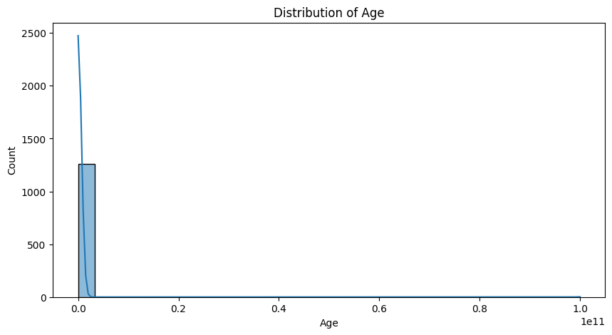

```python
# Age
# Plot for numerical feature 'Age'
plt.figure(figsize=(10,5))
sns.histplot(df['Age'], kde=True, bins=30)
plt.title("Distribution of Age")
plt.show()
```

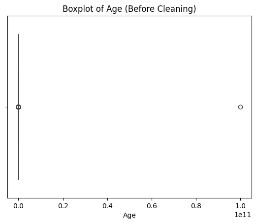

```python
sns.boxplot(x=df['Age'])
plt.title('Boxplot of Age (Before Cleaning)')
plt.show()
```

```python
print(df['Age'].describe())
print(df['Age'].unique())
```

```
count    1.259000e+03
mean     7.942815e+07
std      2.818299e+09
min     -1.726000e+03
25%      2.700000e+01
50%      3.100000e+01
75%      3.600000e+01
max      1.000000e+11
Name: Age, dtype: float64
[         37          44          32          31          33          35
          39          42          23          29          36          27
          46          41          34          30          40          38
          50          24          18          28          26          22
          19          25          45          21         -29          43
          56          60          54         329          55 99999999999
          48          20          57          58          47          62
          51          65          49       -1726           5          53
          61           8          11          -1          72]
```

Age attribute has:

- A huge mean (7.9e+07) and max (1.0e+11) which is totally off.
- A min of -1726 and some other impossible ages like -29, 5, 8, 11
- Valid ages should be somewhere between 18 and 75.

```python
# Replace obvious errors with NaN (if not a valid number)
df['Age_cleaned'] = pd.to_numeric(df['Age'], errors='coerce')

# Filter to keep only realistic ages (18 to 100)
df = df[(df['Age_cleaned'] >= 18) & (df['Age_cleaned'] <= 100)].copy()

# Check the cleaned stats
print(df['Age_cleaned'].describe())
```

```
count    1251.000000
mean       32.076739
std         7.288272
min        18.000000
25%        27.000000
50%        31.000000
75%        36.000000
max        72.000000
Name: Age_cleaned, dtype: float64
```

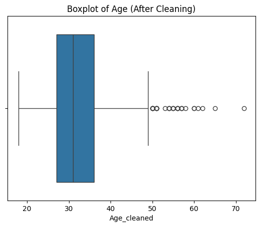

```
Number of outliers: 32
38      50
574     50
606     50
581     50
1106    50
898     50
527     51
895     51
856     51
1159    51
904     51
911     53
652     54
347     54
```

[output cut: 19 more lines]

```python
# outliers
sns.boxplot(x=df['Age_cleaned'])
plt.title('Boxplot of Age (After Cleaning)')
plt.show()

Q1 = df['Age_cleaned'].quantile(0.25)
Q3 = df['Age_cleaned'].quantile(0.75)
IQR = Q3 - Q1

# Define outlier bounds
lower_bound = Q1 - 1.5 * IQR
upper_bound = Q3 + 1.5 * IQR

# Identify outliers
outliers = df[(df['Age_cleaned'] < lower_bound) | (df['Age_cleaned'] > upper_bound)]
print(f"Number of outliers: {len(outliers)}")
print(outliers['Age_cleaned'].sort_values())
```

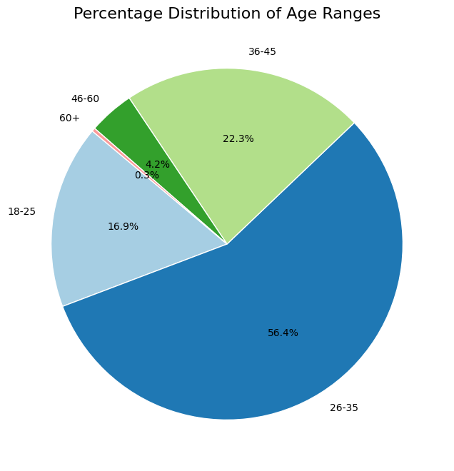

```python
# Define age ranges
bins = [18, 25, 35, 45, 60, 100]
labels = ['18-25', '26-35', '36-45', '46-60', '60+']

# Create a new column with the age group for cleaned data
df['Age_Group'] = pd.cut(df['Age_cleaned'], bins=bins, labels=labels, right=True)

# Count the number of people in each group
age_counts = df['Age_Group'].value_counts().sort_index()

# Plot pie chart
plt.figure(figsize=(8, 8))
plt.pie(age_counts, labels=age_counts.index, autopct='%1.1f%%', startangle=140,
        colors=plt.cm.Paired.colors, wedgeprops={'edgecolor': 'white'})

plt.title('Percentage Distribution of Age Ranges', fontsize=16)
plt.show()
```

```python
# Function to plot countplots for categorical features
def plot_count(feature, title, rotation=0):
    plt.figure(figsize=(10,5))
    sns.countplot(data=df, x=feature, order=df[feature].value_counts().index)
    plt.title(title)
    plt.xticks(rotation=rotation)
    plt.show()
```

```python
# Function to plot count plots and percentages for categorical features
def plot_count_with_percentage(feature, title, rotation=0):
    plt.figure(figsize=(10,5))
    gender_counts = df[feature].value_counts()
    sns.countplot(data=df, x=feature, order=gender_counts.index)

    # Add percentages on top of the bars
    total = len(df)
    for p in plt.gca().patches:
        height = p.get_height()
        percentage = (height / total) * 100
        plt.gca().text(p.get_x() + p.get_width() / 2., height + 10, f'{percentage:.1f}%',
                       ha='center', fontsize=12, color='black')

    plt.title(title)
    plt.xticks(rotation=rotation)
    plt.show()
```

```python
print(df['Gender'].describe())
print(df['Gender'].unique())
```

```
count     1251
unique      46
top       Male
freq       612
Name: Gender, dtype: object
['Female' 'M' 'Male' 'male' 'female' 'm' 'Male-ish' 'maile' 'Trans-female'
 'Cis Female' 'F' 'something kinda male?' 'Cis Male' 'Woman' 'f' 'Mal'
 'Male (CIS)' 'queer/she/they' 'non-binary' 'Femake' 'woman' 'Make' 'Nah'
 'Enby' 'fluid' 'Genderqueer' 'Female ' 'Androgyne' 'Agender'
 'cis-female/femme' 'Guy (-ish) ^_^' 'male leaning androgynous' 'Male '
 'Man' 'Trans woman' 'msle' 'Neuter' 'Female (trans)' 'queer'
 'Female (cis)' 'Mail' 'cis male' 'Malr' 'femail' 'Cis Man'
 'ostensibly male, unsure what that really means']
```

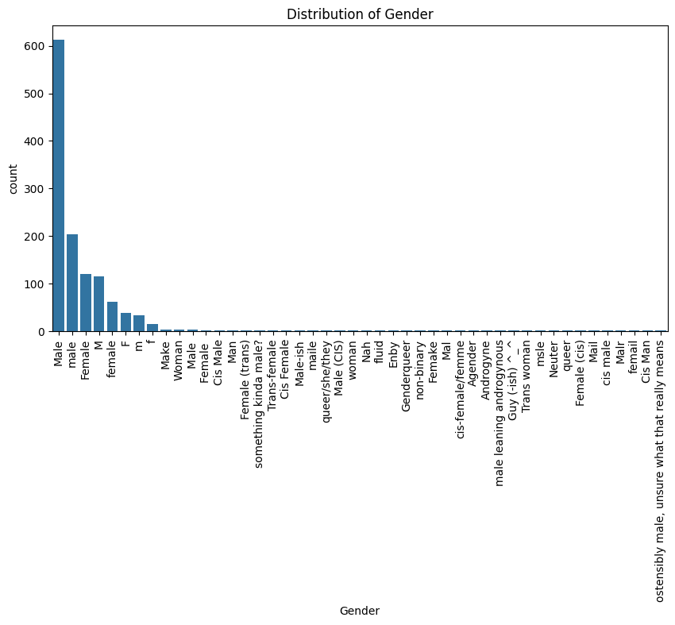

```python
# Plot distribution of 'Gender'
plot_count('Gender', 'Distribution of Gender', 90)
```

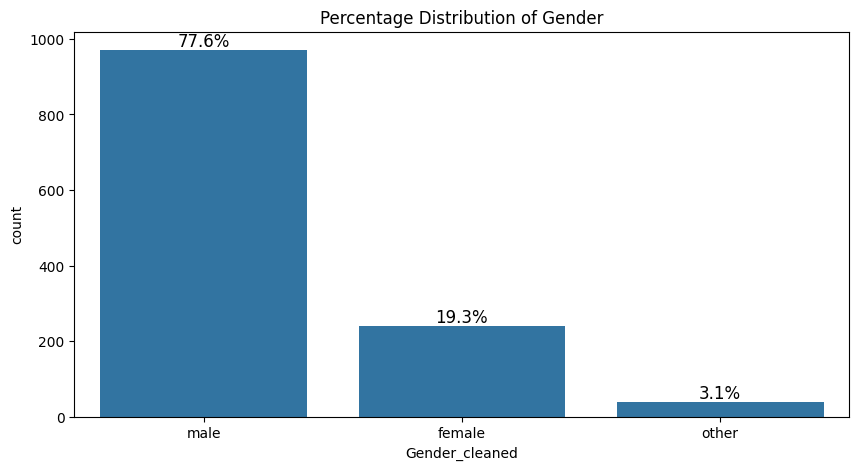

```python
# Clean 'Gender' column
gender_mapping = {
    'male': 'male', 'm': 'male', 'mail': 'male', 'maile': 'male', 'man': 'male', 'mal': 'male',
    'female': 'female', 'f': 'female', 'femail': 'female', 'woman': 'female'
}

# Create a new 'Gender_cleaned' column with standardized values
df['Gender_cleaned'] = df['Gender'].str.lower().map(gender_mapping).fillna('other')


# Plot the gender distribution with percentages
plot_count_with_percentage('Gender_cleaned', 'Percentage Distribution of Gender')
```

```python
print(df['Country'].describe())
print(df['Country'].unique())
```

```
count              1251
unique               46
top       United States
freq                746
Name: Country, dtype: object
['United States' 'Canada' 'United Kingdom' 'Bulgaria' 'France' 'Portugal'
 'Netherlands' 'Switzerland' 'Poland' 'Australia' 'Germany' 'Russia'
 'Mexico' 'Brazil' 'Slovenia' 'Costa Rica' 'Austria' 'Ireland' 'India'
 'South Africa' 'Italy' 'Sweden' 'Colombia' 'Latvia' 'Romania' 'Belgium'
 'New Zealand' 'Spain' 'Finland' 'Uruguay' 'Israel'
 'Bosnia and Herzegovina' 'Hungary' 'Singapore' 'Japan' 'Nigeria'
 'Croatia' 'Norway' 'Thailand' 'Denmark' 'Greece' 'Moldova' 'Georgia'
 'China' 'Czech Republic' 'Philippines']
```

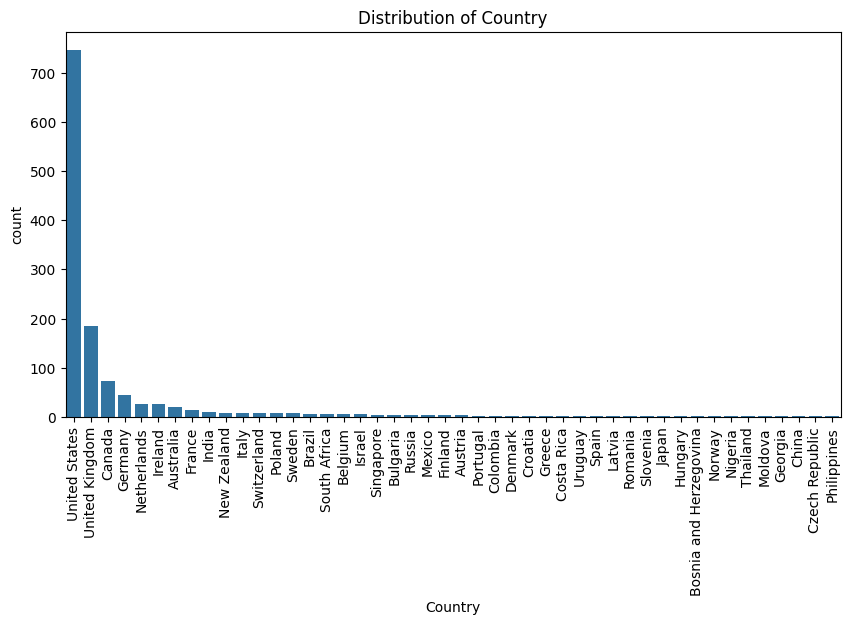

```python
# Plot distribution of 'Country'
plot_count('Country', 'Distribution of Country', 90)
```

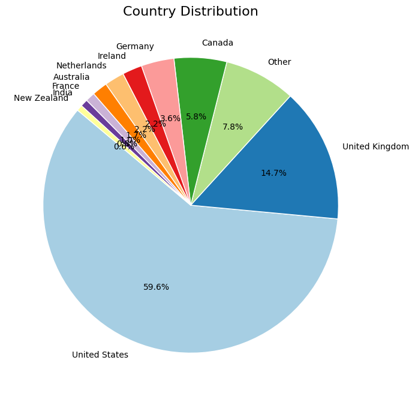

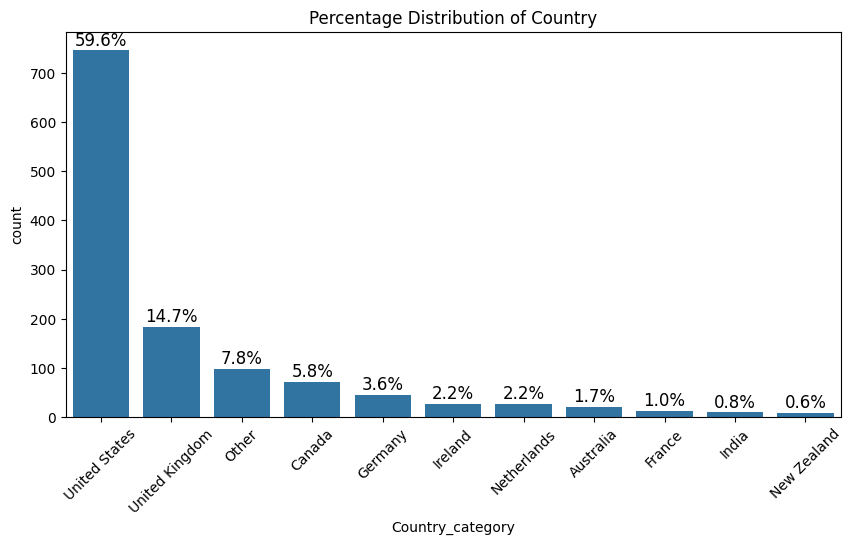

```python
# Count the occurrences of each country
country_counts = df['Country'].value_counts()

# Keep top 10 countries and categorize others as 'Other'
top_countries = country_counts.head(10)
df['Country_category'] = df['Country'].apply(lambda x: x if x in top_countries.index else 'Other')

# Count the occurrences of the new 'Country_category' column
country_category_counts = df['Country_category'].value_counts()

# Plot pie chart for the new categorization
plt.figure(figsize=(8,8))
plt.pie(country_category_counts, labels=country_category_counts.index, autopct='%1.1f%%', startangle=140,
        colors=plt.cm.Paired.colors, wedgeprops={'edgecolor':'white'})

plt.title('Country Distribution', fontsize=16)
plt.show()

plot_count_with_percentage('Country_category', 'Percentage Distribution of Country', 45)
```

```
Number of respondents NOT from US: 505
Number of missing values in state: 513
```

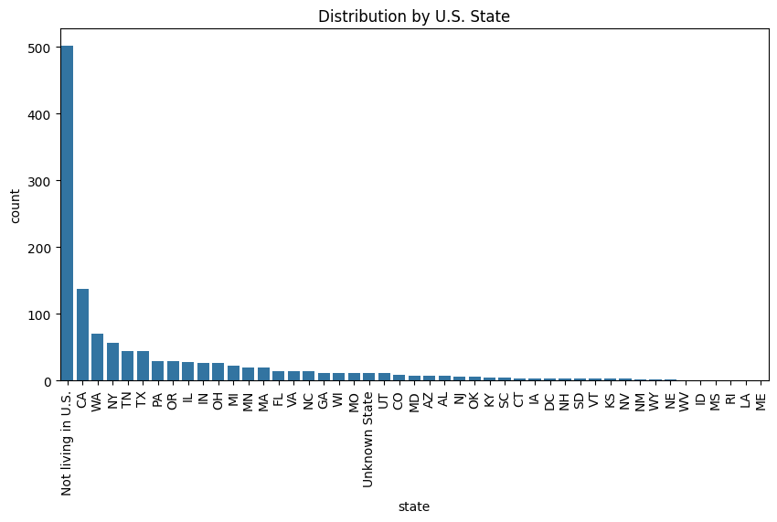

```python
# state

#filling all the previous missing values back to NaN, so we can count missing values
df['state'] = df['state'].replace('Not living in U.S.', np.nan)
df['state'] = df['state'].replace('Unknown State', np.nan)

#checking if the number of missing values in state is equal to the number of people not living in U.S
non_us_count = df[df['Country'] != 'United States'].shape[0]
print("Number of respondents NOT from US:", non_us_count)
missing_state_count = df['state'].isna().sum()
print("Number of missing values in state:", missing_state_count)

#changing missing values accordingly to if they live in U.S or not
df.loc[(df['Country'] != 'United States') & (df['state'].isna()), 'state'] = 'Not living in U.S.'
df.loc[(df['Country'] == 'United States') & (df['state'].isna()), 'state'] = 'Unknown State'

#ploting the data
plot_count('state', 'Distribution by U.S. State', 90)
```

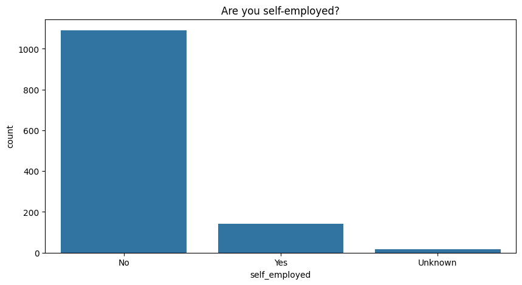

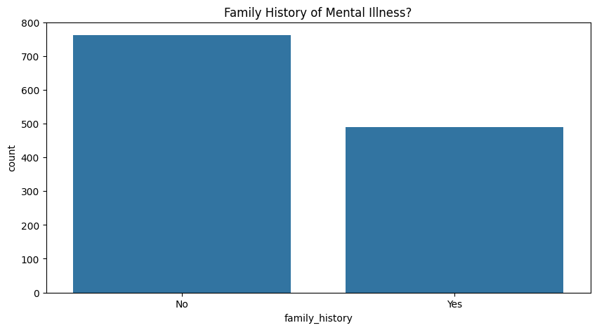

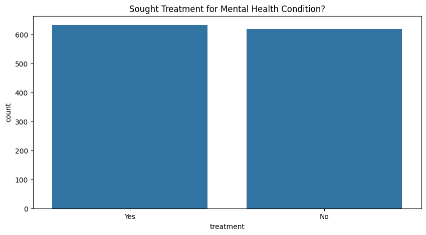

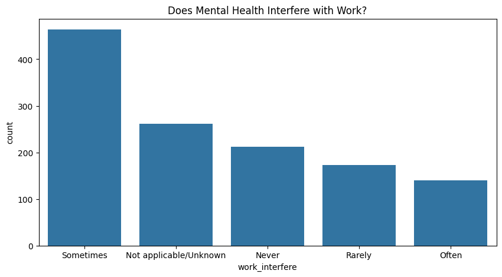

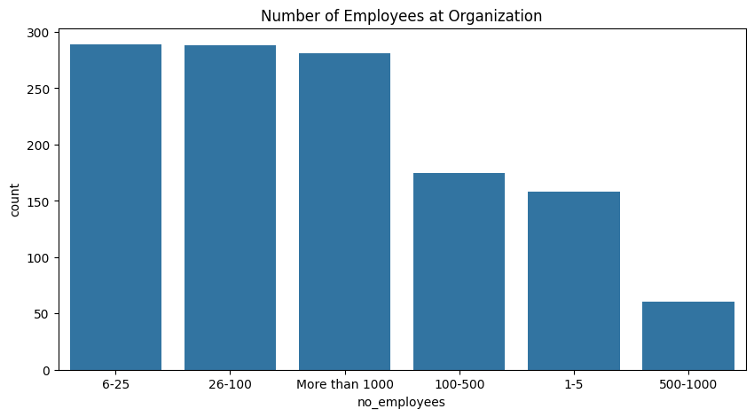

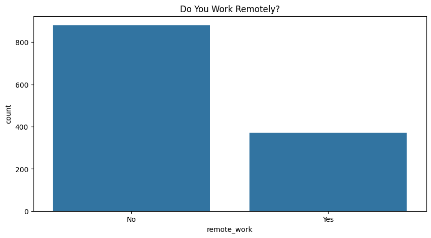

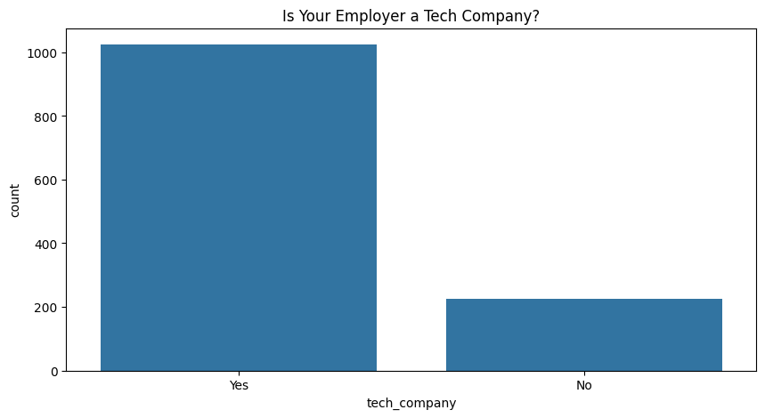

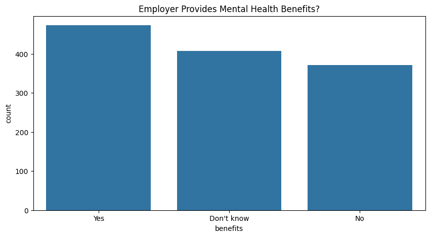

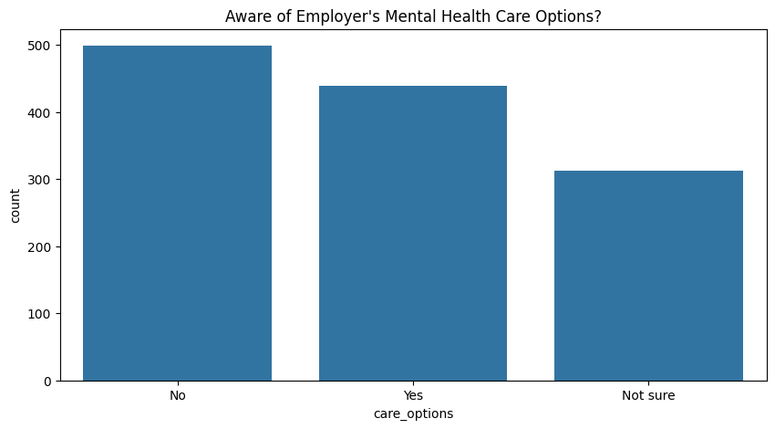

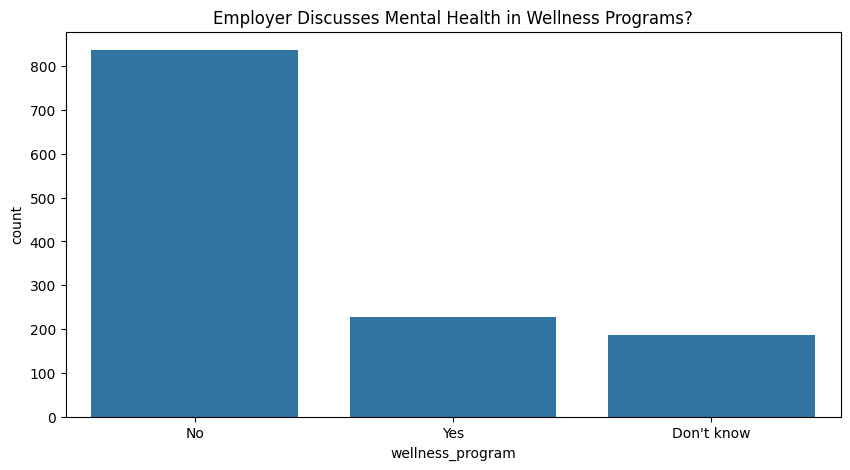

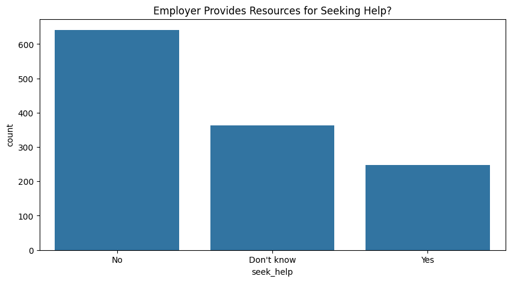

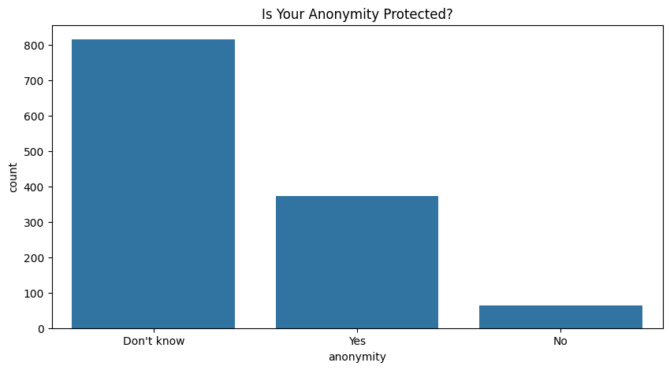

[9 more figures not shown]

```python
# List of categorical features to plot
categorical_features = [
    ("self_employed", "Are you self-employed?"),
    ("family_history", "Family History of Mental Illness?"),
    ("treatment", "Sought Treatment for Mental Health Condition?"),
    ("work_interfere", "Does Mental Health Interfere with Work?"),
    ("no_employees", "Number of Employees at Organization"),
    ("remote_work", "Do You Work Remotely?"),
    ("tech_company", "Is Your Employer a Tech Company?"),
    ("benefits", "Employer Provides Mental Health Benefits?"),
    ("care_options", "Aware of Employer's Mental Health Care Options?"),
    ("wellness_program", "Employer Discusses Mental Health in Wellness Programs?"),
    ("seek_help", "Employer Provides Resources for Seeking Help?"),
    ("anonymity", "Is Your Anonymity Protected?"),
    ("leave", "Ease of Taking Mental Health Leave"),
    ("mental_health_consequence", "Negative Consequences for Discussing Mental Health?"),
    ("phys_health_consequence", "Negative Consequences for Discussing Physical Health?"),
    ("coworkers", "Willingness to Discuss with Coworkers?"),
    ("supervisor", "Willingness to Discuss with Supervisor?"),
    ("mental_health_interview", "Would You Bring Up Mental Health in an Interview?"),
    ("phys_health_interview", "Would You Bring Up Physical Health in an Interview?"),
    ("mental_vs_physical", "Employer Takes Mental and Physical Health Equally Seriously?"),
    ("obs_consequence", "Observed Negative Consequences for Coworkers?")
]

#filling missing values for self-employed attribute to Unknown
df['self_employed'] = df['self_employed'].fillna('Unknown')
#filling missing values for self-employed attribute to Not applicable/Unknown
df['work_interfere'] = df['work_interfere'].fillna('Not applicable/Unknown')

# Loop through categorical features and plot
for item in categorical_features:
    feature = item[0]
    title = item[1]
    rotation = item[2] if len(item) > 2 else 0
    plot_count(feature, title, rotation)
```

```python
#comments

# Drop missing values in 'comments' column
comments = df['comments'].dropna()

# Display all comments
for comment in comments:
    print(comment)
    print()
```

[output not shown]

[output cut: 266 more lines]

```
I openly discuss my mental health struggles. I have found that doing so encourages people who also struggle to seek treatment. I'm willing to risk losing the support of people who don't understand if it helps those who understand all too well.

Just starting a new job hence the numerous I don't know selections.

The data will be skewed for self-employed people as the questions contain some bias.Having said that: being self-employed I *choose* to work for companies which want to employ *me* not just my skills but including my opinions my life-experience etc. If a potential contract/job doesn't *feel* right I…

Although my employer does everything they can to accommodate employees with mental health problems when those individuals cannot carry out any work assigned to them (even over the course of months) they appear to have no alternative but to terminate their employment. However I believe this would be …

I work at a large university with a track record of health and wellbeing support

i'm in a country with social health care so my options are not dependant on my employer. this makes a few of the early questions less relevant than they would be for a resident of the US.

In australia all organisations of a certain size have to provide free access to a 'employee assistance program' to discuss work and personal issues.EAPs are an external provider totally confidential and anonymous (ring up andsay the name of who you work for - so they know to bill your work)  and the…

Bipolar disorder
```

#### **Correlations Between Attribute Values**

This section presents chosen correlations between attributes along with short interpretation of the results.

```python
# functions for fast interpretation of the results
def check_corr_results_point_biserial(statistic, pvalue):
    print('Based on correlation coefficient ')
    if statistic < 0:
        print("there is a negative corelation between variables.")
    elif statistic > 0:
        print("there is a positive corelation between variables.")
    else:
        print("there is no corelation between variables.")

    print('Based on p value with significance level 0.05 ')
    if pvalue > 0.05:
        print("we cannot reject null hypothesis - there is no corelation between variables.")
    else:
        print("we can reject null hypothesis - there is corelation between variables.")

    print("Strength of the correlation: ")
    if abs(statistic) >= 0 and abs(statistic) < 0.1:
        print("no correlation.")
    elif abs(statistic) >= 0.1 and abs(statistic) < 0.3:
        print("little correlation.")
    elif abs(statistic) >= 0.3 and abs(statistic) < 0.5:
        print("medium correlation.")
    elif abs(statistic) >= 0.5 and abs(statistic) < 0.7:
        print("high correlation.")
    else:
        print("very high correlation.")

def check_corr_results_cramers_v(statistic):
    print("Strength of the correlation: ")
    if abs(statistic) >= 0 and abs(statistic) < 0.1:
        print("no correlation.")
    elif abs(statistic) >= 0.1 and abs(statistic) < 0.3:
        print("little correlation.")
    elif abs(statistic) >= 0.3 and abs(statistic) < 0.5:
        print("medium correlation.")
    elif abs(statistic) >= 0.5 and abs(statistic) < 0.7:
        print("high correlation.")
    else:
        print("very high correlation.")

# function for calculating Cramer's V
def cramers_v(var1, var2):
    contingency_table = pd.crosstab(var1, var2)
    chi, pvalue, deg_f, freq = stats.chi2_contingency(contingency_table)
    n = df.shape[0]
    min_val = np.min(contingency_table.shape)-1
    cramers_v = np.sqrt((chi/n)/min_val)
    return cramers_v
```

#### Correlation between age and treatment attributes

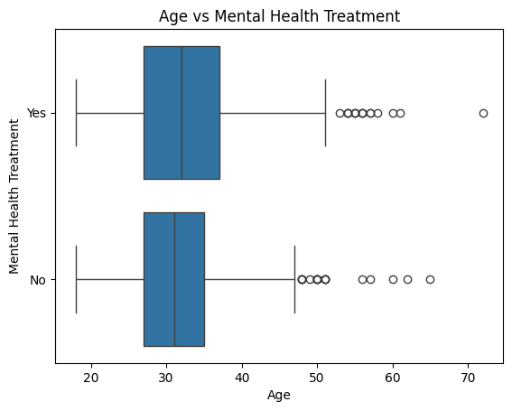

```
Point-Biserial Correlation statistics: 0.07362737182852744 p value: 0.009184883179688933
Based on correlation coefficient
there is a positive corelation between variables.
Based on p value with significance level 0.05
we can reject null hypothesis - there is corelation between variables.
Strength of the correlation:
no correlation.
```

```python
# Boxplot of Age (cleaned) and Treatment variables
sns.boxplot(x='Age_cleaned', y='treatment', data=df)
plt.title("Age vs Mental Health Treatment")
plt.xlabel('Age')
plt.ylabel('Mental Health Treatment')
plt.show()

# Since Age is numberical/quantitative and Treatment is dichotomous - Apply Point-Biserial Correlation
df['treatment_bin'] = df['treatment'].map({'Yes':1, 'No':0})
stat, pvalue = stats.pointbiserialr(df['treatment_bin'], df['Age_cleaned'])
print('Point-Biserial Correlation statistics: ' + str(stat) + ' p value: ' + str(pvalue))
check_corr_results_point_biserial(stat, pvalue)
```

#### Matrix and Heatmap of other correlations of chosen attributes

Note: Cells where correlation between the same attribute should be calculated is set to 0 in order to avoid disruptance in the heatmap.  
Cramer's V is chosen for calculations because only categorical attributes will be taken into account.

```
Cramer's V results:
```

|  | Age_Group | Gender_cleaned | Country | state | self_employed | family_history | treatment | work_interfere | no_employees | remote_work | ... | anonymity | leave | mental_health_consequence | phys_health_consequence | coworkers | supervisor | mental_health_interview | phys_health_interview | mental_vs_physical | obs_consequence |
| --- | --- | --- | --- | --- | --- | --- | --- | --- | --- | --- | --- | --- | --- | --- | --- | --- | --- | --- | --- | --- | --- |
| Age_Group | 0.000000 | 0.065110 | 0.206943 | 0.232244 | 0.070501 | 0.050846 | 0.066238 | 0.060731 | 0.101462 | 0.136751 | ... | 0.057589 | 0.062130 | 0.071852 | 0.074577 | 0.063499 | 0.048393 | 0.049985 | 0.061974 | 0.048498 | 0.108694 |
| Gender_cleaned | 0.065110 | 0.000000 | 0.163394 | 0.220807 | 0.039867 | 0.149654 | 0.201557 | 0.115593 | 0.099488 | 0.009071 | ... | 0.028858 | 0.068824 | 0.091719 | 0.083442 | 0.040785 | 0.091290 | 0.100630 | 0.099245 | 0.030244 | 0.089785 |
| Country | 0.206943 | 0.163394 | 0.000000 | 0.153368 | 0.232442 | 0.214500 | 0.233254 | 0.210109 | 0.219688 | 0.237484 | ... | 0.245497 | 0.225964 | 0.217952 | 0.261656 | 0.205285 | 0.198594 | 0.267524 | 0.248951 | 0.214577 | 0.248923 |
| state | 0.232244 | 0.220807 | 0.153368 | 0.000000 | 0.210271 | 0.223761 | 0.225852 | 0.190448 | 0.246860 | 0.268458 | ... | 0.207170 | 0.205423 | 0.188789 | 0.204810 | 0.189364 | 0.207053 | 0.214214 | 0.223894 | 0.218141 | 0.198753 |
| self_employed | 0.070501 | 0.039867 | 0.232442 | 0.210271 | 0.000000 | 0.002580 | 0.016451 | 0.084316 | 0.418014 | 0.314728 | ... | 0.096282 | 0.151014 | 0.071470 | 0.045931 | 0.081559 | 0.047329 | 0.095115 | 0.035837 | 0.108746 | 0.068274 |
| family_history | 0.050846 | 0.149654 | 0.214500 | 0.223761 | 0.002580 | 0.000000 | 0.375035 | 0.355758 | 0.090215 | 0.012485 | ... | 0.071575 | 0.075113 | 0.093440 | 0.051207 | 0.011507 | 0.002885 | 0.074462 | 0.063104 | 0.095592 | 0.115255 |
| treatment | 0.066238 | 0.201557 | 0.233254 | 0.225852 | 0.016451 | 0.375035 | 0.000000 | 0.685344 | 0.083961 | 0.024756 | ... | 0.143913 | 0.151939 | 0.126821 | 0.044739 | 0.070488 | 0.035115 | 0.097947 | 0.049712 | 0.116048 | 0.150252 |
| work_interfere | 0.060731 | 0.115593 | 0.210109 | 0.190448 | 0.084316 | 0.355758 | 0.685344 | 0.000000 | 0.080642 | 0.057681 | ... | 0.087700 | 0.115876 | 0.145618 | 0.083295 | 0.048920 | 0.086314 | 0.089316 | 0.060388 | 0.113034 | 0.178879 |
| no_employees | 0.101462 | 0.099488 | 0.219688 | 0.246860 | 0.418014 | 0.090215 | 0.083961 | 0.080642 | 0.000000 | 0.290812 | ... | 0.119502 | 0.119500 | 0.092823 | 0.074106 | 0.106165 | 0.091993 | 0.103318 | 0.099839 | 0.107833 | 0.100826 |
| remote_work | 0.136751 | 0.009071 | 0.237484 | 0.268458 | 0.314728 | 0.012485 | 0.024756 | 0.057681 | 0.290812 | 0.000000 | ... | 0.010019 | 0.106700 | 0.061879 | 0.023248 | 0.081150 | 0.048840 | 0.083190 | 0.040207 | 0.080231 | 0.040685 |
| tech_company | 0.111800 | 0.076415 | 0.190335 | 0.275148 | 0.080367 | 0.047517 | 0.030443 | 0.052742 | 0.256416 | 0.129751 | ... | 0.066315 | 0.060644 | 0.124612 | 0.073953 | 0.073908 | 0.050394 | 0.082958 | 0.035763 | 0.123410 | 0.063795 |
| benefits | 0.126541 | 0.112472 | 0.366798 | 0.360160 | 0.201178 | 0.149249 | 0.225648 | 0.134360 | 0.349995 | 0.106199 | ... | 0.283553 | 0.204867 | 0.083260 | 0.075045 | 0.054204 | 0.041173 | 0.043315 | 0.079860 | 0.146849 | 0.111002 |
| care_options | 0.089617 | 0.094500 | 0.241196 | 0.233987 | 0.039033 | 0.121721 | 0.272528 | 0.161405 | 0.163743 | 0.028340 | ... | 0.292515 | 0.129254 | 0.054656 | 0.025382 | 0.038053 | 0.081380 | 0.027899 | 0.031741 | 0.146567 | 0.098619 |
| wellness_program | 0.117919 | 0.056002 | 0.220645 | 0.233951 | 0.049004 | 0.060939 | 0.092156 | 0.102463 | 0.267878 | 0.077333 | ... | 0.216421 | 0.142005 | 0.122684 | 0.039117 | 0.065242 | 0.096418 | 0.064838 | 0.052184 | 0.205766 | 0.096052 |
| seek_help | 0.126570 | 0.048631 | 0.246697 | 0.291229 | 0.094744 | 0.055355 | 0.092541 | 0.123562 | 0.308774 | 0.054042 | ... | 0.262538 | 0.188528 | 0.099156 | 0.069713 | 0.047286 | 0.085461 | 0.025209 | 0.066233 | 0.203663 | 0.134858 |
| anonymity | 0.057589 | 0.028858 | 0.245497 | 0.207170 | 0.096282 | 0.071575 | 0.143913 | 0.087700 | 0.119502 | 0.010019 | ... | 0.000000 | 0.271070 | 0.197800 | 0.148635 | 0.093344 | 0.152218 | 0.066209 | 0.037771 | 0.246529 | 0.155820 |
| leave | 0.062130 | 0.068824 | 0.225964 | 0.205423 | 0.151014 | 0.075113 | 0.151939 | 0.115876 | 0.119500 | 0.106700 | ... | 0.271070 | 0.000000 | 0.301824 | 0.177903 | 0.179136 | 0.223235 | 0.131641 | 0.074916 | 0.351529 | 0.257793 |
| mental_health_consequence | 0.071852 | 0.091719 | 0.217952 | 0.188789 | 0.071470 | 0.093440 | 0.126821 | 0.145618 | 0.092823 | 0.061879 | ... | 0.197800 | 0.301824 | 0.000000 | 0.397469 | 0.337687 | 0.429727 | 0.245240 | 0.080962 | 0.329736 | 0.228998 |
| phys_health_consequence | 0.074577 | 0.083442 | 0.261656 | 0.204810 | 0.045931 | 0.051207 | 0.044739 | 0.083295 | 0.074106 | 0.023248 | ... | 0.148635 | 0.177903 | 0.397469 | 0.000000 | 0.168092 | 0.247904 | 0.090395 | 0.142038 | 0.174886 | 0.167023 |
| coworkers | 0.063499 | 0.040785 | 0.205285 | 0.189364 | 0.081559 | 0.011507 | 0.070488 | 0.048920 | 0.106165 | 0.081150 | ... | 0.093344 | 0.179136 | 0.337687 | 0.168092 | 0.000000 | 0.438346 | 0.242768 | 0.114241 | 0.173184 | 0.067259 |
| supervisor | 0.048393 | 0.091290 | 0.198594 | 0.207053 | 0.047329 | 0.002885 | 0.035115 | 0.086314 | 0.091993 | 0.048840 | ... | 0.152218 | 0.223235 | 0.429727 | 0.247904 | 0.438346 | 0.000000 | 0.243395 | 0.117804 | 0.231591 | 0.111990 |
| mental_health_interview | 0.049985 | 0.100630 | 0.267524 | 0.214214 | 0.095115 | 0.074462 | 0.097947 | 0.089316 | 0.103318 | 0.083190 | ... | 0.066209 | 0.131641 | 0.245240 | 0.090395 | 0.242768 | 0.243395 | 0.000000 | 0.375618 | 0.152875 | 0.093463 |
| phys_health_interview | 0.061974 | 0.099245 | 0.248951 | 0.223894 | 0.035837 | 0.063104 | 0.049712 | 0.060388 | 0.099839 | 0.040207 | ... | 0.037771 | 0.074916 | 0.080962 | 0.142038 | 0.114241 | 0.117804 | 0.375618 | 0.000000 | 0.079279 | 0.034839 |
| mental_vs_physical | 0.048498 | 0.030244 | 0.214577 | 0.218141 | 0.108746 | 0.095592 | 0.116048 | 0.113034 | 0.107833 | 0.080231 | ... | 0.246529 | 0.351529 | 0.329736 | 0.174886 | 0.173184 | 0.231591 | 0.152875 | 0.079279 | 0.000000 | 0.292942 |
| obs_consequence | 0.108694 | 0.089785 | 0.248923 | 0.198753 | 0.068274 | 0.115255 | 0.150252 | 0.178879 | 0.100826 | 0.040685 | ... | 0.155820 | 0.257793 | 0.228998 | 0.167023 | 0.067259 | 0.111990 | 0.093463 | 0.034839 | 0.292942 | 0.000000 |

25 rows × 25 columns

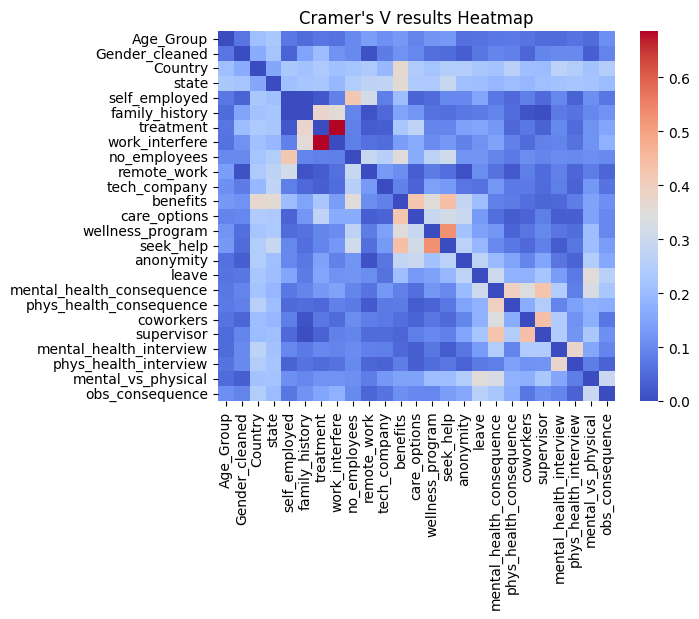

```python
# variables worth checking for cramer's v correlation matrix:

col = ['Age_Group', 'Gender_cleaned', 'Country', 'state', 'self_employed', 'family_history', 'treatment', 'work_interfere', 'no_employees', 'remote_work', 'tech_company', 'benefits',
       'care_options', 'wellness_program', 'seek_help', 'anonymity', 'leave', 'mental_health_consequence', 'phys_health_consequence', 'coworkers', 'supervisor',
       'mental_health_interview', 'phys_health_interview', 'mental_vs_physical', 'obs_consequence']

cramers_v_matrix = pd.DataFrame(np.zeros((len(col), len(col))), columns=col, index=col)

for col1 in col:
    for col2 in col:
        if col2 != col1:
            cramers_v_matrix.loc[col1, col2] = cramers_v(df[col1], df[col2])
print("Cramer's V results: ")
display(cramers_v_matrix)

sns.heatmap(cramers_v_matrix, cmap='coolwarm')
plt.title("Cramer's V results Heatmap")
```

#### Gender Correlation Insights

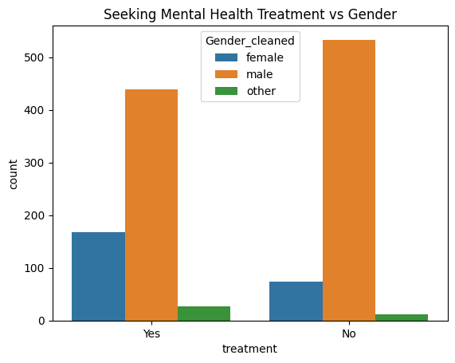

```
Cramer's V result: 0.20155696026035333
Strength of the correlation:
little correlation.
```

```python
# PLot of Treatment attribute between Genders
sns.countplot(x='treatment', hue='Gender_cleaned', data=df)
plt.title("Seeking Mental Health Treatment vs Gender")
plt.show()
# Cramer's V results
cramers_v_result = cramers_v(df['treatment'], df['Gender_cleaned'])
print("Cramer's V result: " + str(cramers_v_result))
check_corr_results_cramers_v(cramers_v_result)
```

#### Interpretation

Male respondents tend not to seek treatment for mental health condition while female respondents and people of other genders tend to seek treatment for mental health condition.

#### Country Correlations Insights

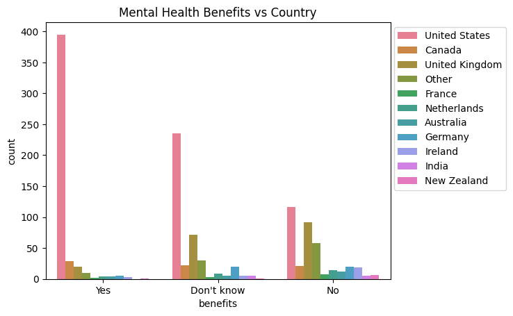

```
Cramer's V result: 0.3667978306591493
Strength of the correlation:
medium correlation.
```

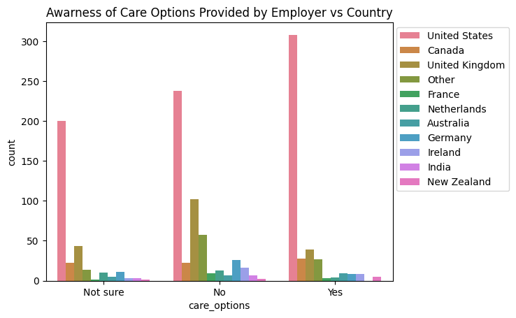

```
Cramer's V result: 0.2411958172262241
Strength of the correlation:
little correlation.
```

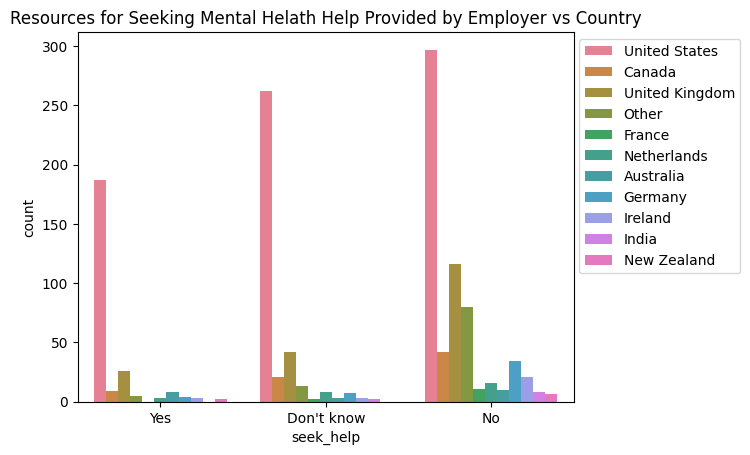

```
Cramer's V result: 0.24669707421923315
Strength of the correlation:
little correlation.
```

```python
# PLot of Benefit attribute between Countries
#NOTICE: Cramer's V is calculated taking into account all countries, but plots show only top countries for better readibility of the plots.
sns.countplot(x='benefits', hue='Country_category', data=df)
plt.title("Mental Health Benefits vs Country")
plt.legend(bbox_to_anchor=(1.35, 1))
plt.show()
# Cramer's V results
cramers_v_result = cramers_v(df['benefits'], df['Country'])
print("Cramer's V result: " + str(cramers_v_result))
check_corr_results_cramers_v(cramers_v_result)

# PLot of Care Options attribute between Countries
sns.countplot(x='care_options', hue='Country_category', data=df)
plt.title("Awarness of Care Options Provided by Employer vs Country")
plt.legend(bbox_to_anchor=(1.35, 1))
plt.show()
# Cramer's V results
cramers_v_result = cramers_v(df['care_options'], df['Country'])
print("Cramer's V result: " + str(cramers_v_result))
check_corr_results_cramers_v(cramers_v_result)

# PLot of Seek Help attribute between Countries
sns.countplot(x='seek_help', hue='Country_category', data=df)
plt.title("Resources for Seeking Mental Helath Help Provided by Employer vs Country")
plt.legend(bbox_to_anchor=(1.35, 1))
plt.show()
# Cramer's V results
cramers_v_result = cramers_v(df['seek_help'], df['Country'])
print("Cramer's V result: " + str(cramers_v_result))
check_corr_results_cramers_v(cramers_v_result)
```

#### Interpretation

Respondents working in the USA are showing the trend that companies offer mental health benefits and employees are aware of mental health calre options provided. However most companies don't provide resources for seeking help for mental health.

It seems that tech companies in the UK, Germany and many other countries, especially European ones tend not to provide benefits or resources for mental health care for their employees. However, we suspect that there is an underlying reason behind this trend and we will discuss this in details in the Data Quality section.

#### Treatment Correlations Insights

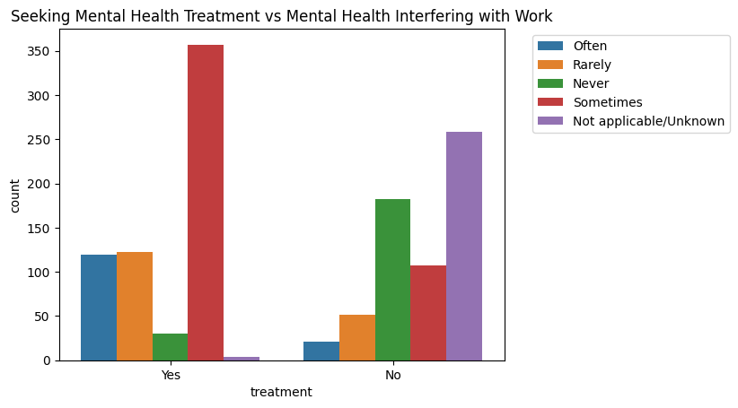

```
Cramer's V result: 0.6853443365421096
Strength of the correlation:
high correlation.
```

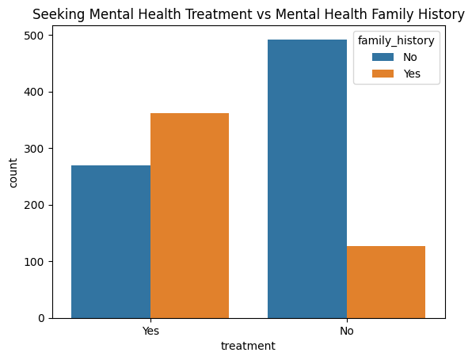

```
Cramer's V result: 0.3750354841924383
Strength of the correlation:
medium correlation.
```

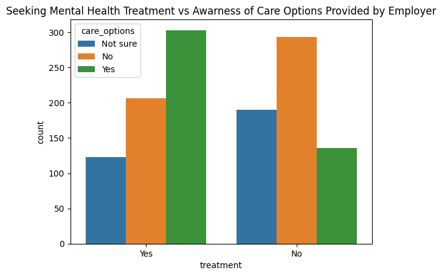

```
Cramer's V result: 0.2725279194428302
Strength of the correlation:
little correlation.
```

```python
# PLot of Work Interfere and Treatment attributes
sns.countplot(x='treatment', hue='work_interfere', data=df)
plt.title("Seeking Mental Health Treatment vs Mental Health Interfering with Work")
plt.legend(bbox_to_anchor=(1.05, 1))
plt.show()
# Cramer's V results
cramers_v_result = cramers_v(df['treatment'], df['work_interfere'])
print("Cramer's V result: " + str(cramers_v_result))
check_corr_results_cramers_v(cramers_v_result)

# PLot of Family History and Treatment attributes
sns.countplot(x='treatment', hue='family_history', data=df)
plt.title("Seeking Mental Health Treatment vs Mental Health Family History")
plt.show()
# Cramer's V results
cramers_v_result = cramers_v(df['treatment'], df['family_history'])
print("Cramer's V result: " + str(cramers_v_result))
check_corr_results_cramers_v(cramers_v_result)

# PLot of Care Options and Treatment attributes
sns.countplot(x='treatment', hue='care_options', data=df)
plt.title("Seeking Mental Health Treatment vs Awarness of Care Options Provided by Employer")
plt.show()
# Cramer's V results
cramers_v_result = cramers_v(df['treatment'], df['care_options'])
print("Cramer's V result: " + str(cramers_v_result))
check_corr_results_cramers_v(cramers_v_result)
```

#### Interpretation

People who are seeking treatment for Mental Health Condition tend to observe their mental health to interfere with work and they are more likely to be aware of menatal health care options provided by their employer.  
People who have mental health history in their family are also more likely to seek treatment.

#### Number Of Employees Correlation Insights

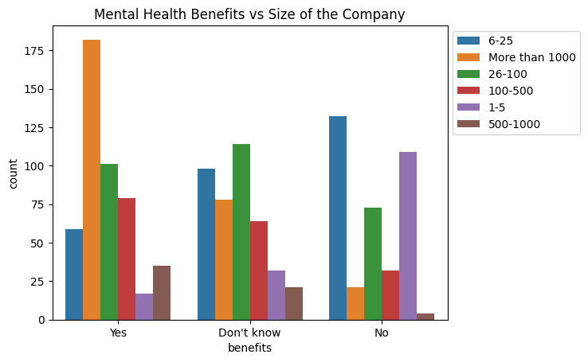

```
Cramer's V result: 0.34999518681187747
Strength of the correlation:
medium correlation.
```

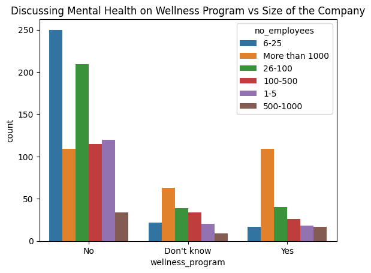

```
Cramer's V result: 0.26787792920457276
Strength of the correlation:
little correlation.
```

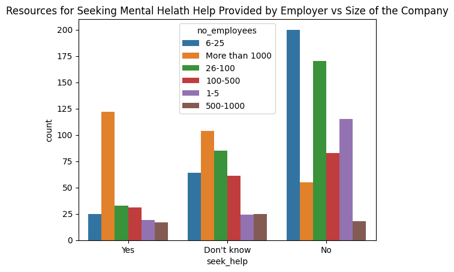

```
Cramer's V result: 0.30877449365477316
Strength of the correlation:
medium correlation.
```

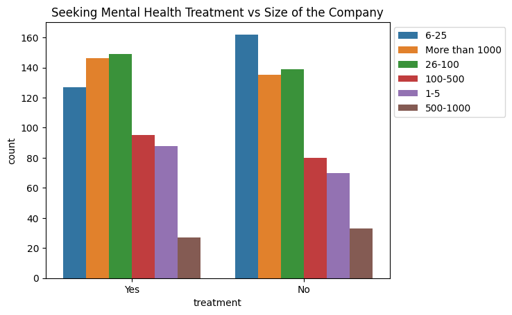

```
Cramer's V result: 0.08396065614070575
Strength of the correlation:
no correlation.
```

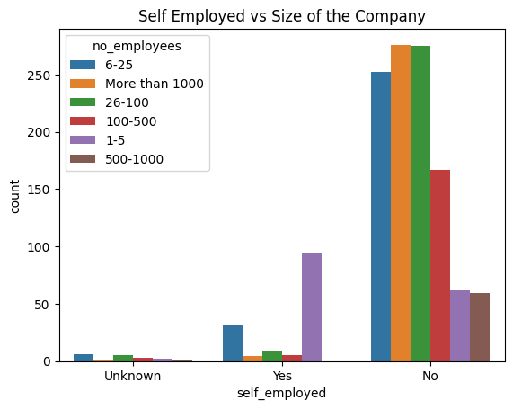

```
Cramer's V result: 0.41801439941692875
Strength of the correlation:
medium correlation.
```

```python
# PLot of Benefits and Number of Employees attributes
sns.countplot(x='benefits', hue='no_employees', data=df)
plt.title("Mental Health Benefits vs Size of the Company")
plt.legend(bbox_to_anchor=(1.35, 1))
plt.show()
# Cramer's V results
cramers_v_result = cramers_v(df['benefits'], df['no_employees'])
print("Cramer's V result: " + str(cramers_v_result))
check_corr_results_cramers_v(cramers_v_result)

# PLot of Wellness Program and Number of Employees attributes
sns.countplot(x='wellness_program', hue='no_employees', data=df)
plt.title("Discussing Mental Health on Wellness Program vs Size of the Company")
plt.show()
# Cramer's V results
cramers_v_result = cramers_v(df['wellness_program'], df['no_employees'])
print("Cramer's V result: " + str(cramers_v_result))
check_corr_results_cramers_v(cramers_v_result)

# PLot of Seek Help and Number of Employees attributes
sns.countplot(x='seek_help', hue='no_employees', data=df)
plt.title("Resources for Seeking Mental Helath Help Provided by Employer vs Size of the Company")
plt.show()
# Cramer's V results
cramers_v_result = cramers_v(df['seek_help'], df['no_employees'])
print("Cramer's V result: " + str(cramers_v_result))
check_corr_results_cramers_v(cramers_v_result)

# PLot of Treatment and Number of Employees attributes
sns.countplot(x='treatment', hue='no_employees', data=df)
plt.title("Seeking Mental Health Treatment vs Size of the Company")
plt.legend(bbox_to_anchor=(1.35, 1))
plt.show()
# Cramer's V results
cramers_v_result = cramers_v(df['treatment'], df['no_employees'])
print("Cramer's V result: " + str(cramers_v_result))
check_corr_results_cramers_v(cramers_v_result)

# PLot of Self Employed and Number of Employees attributes
sns.countplot(x='self_employed', hue='no_employees', data=df)
plt.title("Self Employed vs Size of the Company")
plt.show()
# Cramer's V results
cramers_v_result = cramers_v(df['self_employed'], df['no_employees'])
print("Cramer's V result: " + str(cramers_v_result))
check_corr_results_cramers_v(cramers_v_result)
```

#### Interpretation

There is a visible trend for companies with over 1000 employees to offer mental health benefits and provide resources for seeking help for mental health.

In contrast, small and medium enterprises (SMEs) between 6 to 100 people tend not to offer mental health benefits or don't provide resources for seeking help for mental health. Employers of those companies are also less likely to talk about mental health during wellness programs. This could be due to lack of those programs or lower frequency of organising such events. Additionally looking at the plot of treatment and no_employees attributes, one may even think that there is no correlation at all. It is noticable that employees of small companies (6-25 employees) tend not to seek treatment for mental health. This could mean that such wellness programs are either not so much needed/brought-up in small companies.  
More respondents working in small companies (1-5 employees) are self employed. Most respondents are not self employed and work for larger companies.

#### Benefits Correlation Insights

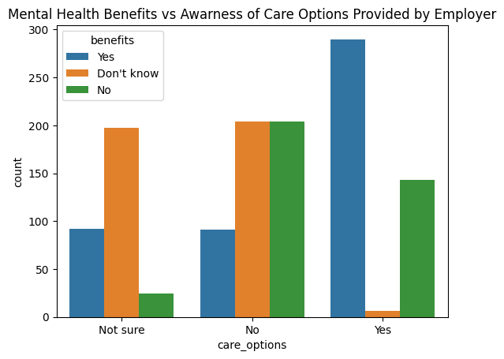

```
Cramer's V result: 0.4256386698849575
Strength of the correlation:
medium correlation.
```

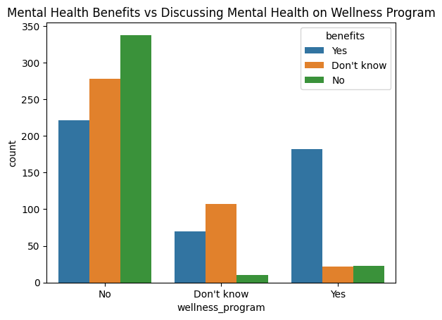

```
Cramer's V result: 0.350303651607756
Strength of the correlation:
medium correlation.
```

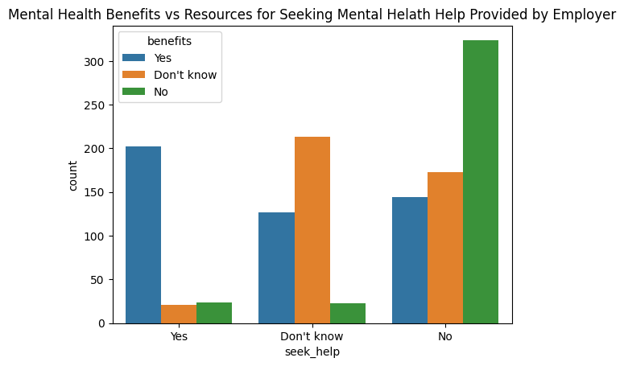

```
Cramer's V result: 0.44125835934821245
Strength of the correlation:
medium correlation.
```

```python
# PLot of Care Options and Benefits attributes
sns.countplot(x='care_options', hue='benefits', data=df)
plt.title("Mental Health Benefits vs Awarness of Care Options Provided by Employer")
plt.show()
# Cramer's V results
cramers_v_result = cramers_v(df['care_options'], df['benefits'])
print("Cramer's V result: " + str(cramers_v_result))
check_corr_results_cramers_v(cramers_v_result)

# PLot of Wellness Program and Benefits attributes
sns.countplot(x='wellness_program', hue='benefits', data=df)
plt.title("Mental Health Benefits vs Discussing Mental Health on Wellness Program")
plt.show()
# Cramer's V results
cramers_v_result = cramers_v(df['wellness_program'], df['benefits'])
print("Cramer's V result: " + str(cramers_v_result))
check_corr_results_cramers_v(cramers_v_result)

# PLot of Seek Help and Benefits attributes
sns.countplot(x='seek_help', hue='benefits', data=df)
plt.title("Mental Health Benefits vs Resources for Seeking Mental Helath Help Provided by Employer")
plt.show()
# Cramer's V results
cramers_v_result = cramers_v(df['seek_help'], df['benefits'])
print("Cramer's V result: " + str(cramers_v_result))
check_corr_results_cramers_v(cramers_v_result)
```

#### Interpretation

This correlations are rather obvious. Companies which offer mental health benefits tend to provide their employees with resources for seeking help for mental health.

Employees are more likey to talk about mental health issues with employers if the companies are providing such benefits but the overall trend is to avoid such topics. This could be due to the mental health beeing seen as private, individual issue or even a "taboo".

#### Wellness Program and Seek Help Correlation Insight

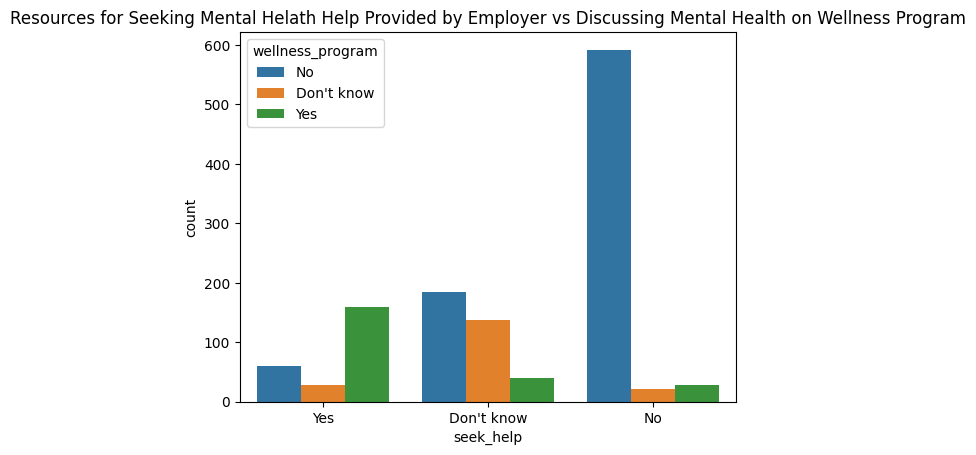

```
Cramer's V result: 0.5292341470209867
Strength of the correlation:
high correlation.
```

```python
# PLot of Seek Help and Wellness Program attributes
sns.countplot(x='seek_help', hue='wellness_program', data=df)
plt.title("Resources for Seeking Mental Helath Help Provided by Employer vs Discussing Mental Health on Wellness Program")
plt.show()
# Cramer's V results
cramers_v_result = cramers_v(df['seek_help'], df['wellness_program'])
print("Cramer's V result: " + str(cramers_v_result))
check_corr_results_cramers_v(cramers_v_result)
```

#### Interpretation

This correlation suggest that if company is providing its employees with resources for seeking help for mental health, the employer will be more likely to discuss mental health on wellness program. From the plot it is clear that more respondents claimed that their employer do not provide resources for seeking help for mental health and does not discuss mental health on wellness program.

#### Mental Health Consequences Correlations Insights

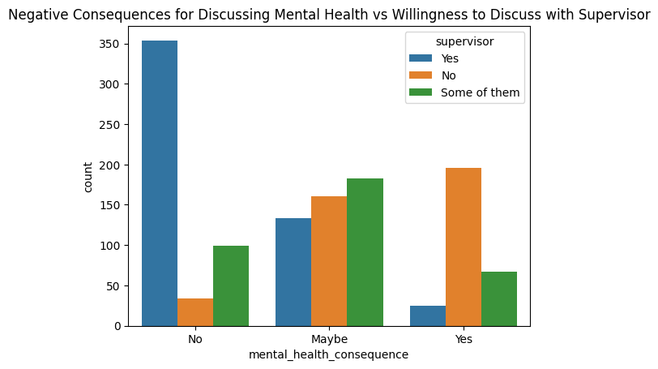

```
Cramer's V result: 0.4297270440973142
Strength of the correlation:
medium correlation.
```

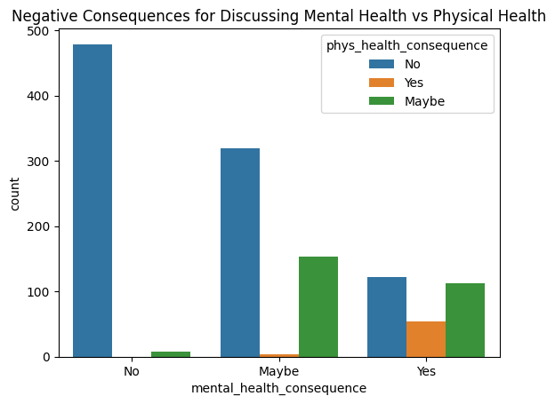

```
Cramer's V result: 0.3974686847897973
Strength of the correlation:
medium correlation.
```

```python
# PLot of Mental Health Consequence and Supervisor attributes
sns.countplot(x='mental_health_consequence', hue='supervisor', data=df)
plt.title("Negative Consequences for Discussing Mental Health vs Willingness to Discuss with Supervisor")
plt.show()
# Cramer's V results
cramers_v_result = cramers_v(df['mental_health_consequence'], df['supervisor'])
print("Cramer's V result: " + str(cramers_v_result))
check_corr_results_cramers_v(cramers_v_result)

# PLot of Mental Health Consequence and Physical Health Consequence  attributes
sns.countplot(x='mental_health_consequence', hue='phys_health_consequence', data=df)
plt.title("Negative Consequences for Discussing Mental Health vs Physical Health")
plt.show()
# Cramer's V results
cramers_v_result = cramers_v(df['mental_health_consequence'], df['phys_health_consequence'])
print("Cramer's V result: " + str(cramers_v_result))
check_corr_results_cramers_v(cramers_v_result)
```

#### Mental and Physical Health Interview Correlation Insights

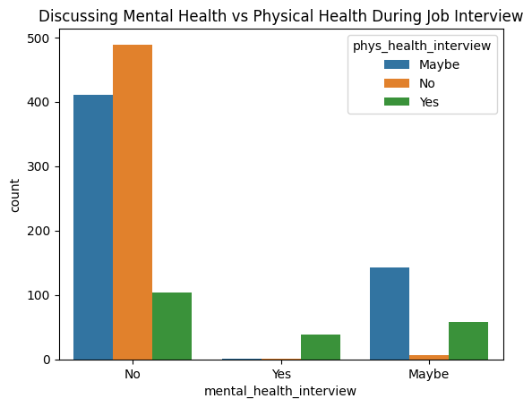

```
Cramer's V result: 0.3756181233638213
Strength of the correlation:
medium correlation.
```

```python
# PLot of Mental Health Interview and Physical Health Interview  attributes
sns.countplot(x='mental_health_interview', hue='phys_health_interview', data=df)
plt.title("Discussing Mental Health vs Physical Health During Job Interview")
plt.show()
# Cramer's V results
cramers_v_result = cramers_v(df['mental_health_interview'], df['phys_health_interview'])
print("Cramer's V result: " + str(cramers_v_result))
check_corr_results_cramers_v(cramers_v_result)
```

#### Interpretation

Respondents who are not willing to discuss physical health with potential employer during interview are also less likely to do so when it comes to mental health.  
Additionally, only people that are willing to discuss physical health during interview with potential employer will discuss mental health.

#### Coworkers and Supervisor Correlation Insight

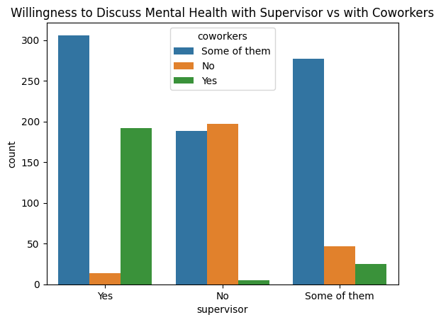

```
Cramer's V result: 0.43834607559873906
Strength of the correlation:
medium correlation.
```

```python
# PLot of Supervisor and Coworker  attributes
sns.countplot(x='supervisor', hue='coworkers', data=df)
plt.title("Willingness to Discuss Mental Health with Supervisor vs with Coworkers")
plt.show()
# Cramer's V results
cramers_v_result = cramers_v(df['supervisor'], df['coworkers'])
print("Cramer's V result: " + str(cramers_v_result))
check_corr_results_cramers_v(cramers_v_result)
```

#### Interpretation

Plot shows that people who are likely to discuss mental health with their coworkers are also likely to do so with their supervisor.

#### **Preliminary findings about the contents of the dataset**

The findings indicate notable trends in how mental health treatment, company size, and workplace support are related. Larger companies tend to offer more mental health resources, while small companies are less likely to provide support. Gender and family history play a role in treatment-seeking behavior, and cultural factors, such as the perception of mental health as a taboo topic, impact discussions in the workplace.

### **Data Quality**

#### **Missing Data & Outliers & Values of Unknown Meaning**

The dataset has **missing values** for the following attributes: state, self-employed, work_interfere and comments.

**State:** The missing values obviously appear in the dataset due to the fact that some people don't live in the U.S., so we counted the amount of people living elswhere and compared it to number of missing values. For people living outside of U.S, we swapped the NaN values to "Not living in U.S", for additional respondents, who live in U.S, but didn't specify their state, we decided to change the missing values to "Unknown state".

**Self-employed:** Here we also keep missing values, but just change them to "Unknown", because we can't verify the reason why some respondents skip this question.

**Work_interfere:** Here we keep missing values, but change them to "Not applicable/Unknown", because we assume that most respondents skip this question since they don't have a mental health condition (Not applicable), but we can't check if that's the reason for all respondents (Unknown).

**Comments:** We drop all the missing comments as we only want to analyze the responses that include some text.

The dataset also has some noticeable **outliers**, especially in the **Age** and **Gender** attributes during the analysis.

**Age:** The outliers are extreme values that fall outside the expected range of ages, such as negative values, positive yet very small values or values greater than 100 years. These outliers may indicate data entry errors or respondents who either don't fit the profile of the target population (e.g., age values like 5 or 8) or they don't want to disclose this information.

It is essential to address these outliers because they can skew the analysis, especially when calculating averages or distributions. We chose to clean the Age attribute by filtering for realistic values (ages between 18 and 100), leaving only valid data for further analysis.

**Gender:** There are a few instances of inconsistent or potentially erroneous entries. For example, in the Gender column, values like "M", "F", "mail" (a typo for "male"), and various capitalizations of "male" and "female" were found. These inconsistencies were addressed by standardizing the Gender values to a consistent set of categories: "male", "female", and "other". Such standardization is crucial for ensuring that categorical variables are properly grouped and analyzed.

#### **Overall Data Integrity**

**Overall, the dataset has good data integrity** — most variables contain expected values and formats, with only some missing values and a few outliers.

However, there are notable **biases affecting data quality and representativeness**:

**Participation Bias:** As an open, voluntary survey hosted by a mental health advocacy group, it likely attracts respondents with personal mental health experiences (78.98% of the responses claimed to have a mental illness based on the 9th variable: work_interfere; 23.1% according to the US National Institute of Mental Health).

**Demographic Skew:** The data leans U.S.-centric (59.6%), with an overrepresentation of men (77.6%) and individuals aged 18-45 (99.5%).

**Limited Applicability:** Certain questions don't apply to self-employed individuals or entrepreneurs, who lack traditional supervisors, HR, or organizational support structures.

**Cultural Context Bias:** Many questions reflect a U.S.-centric view, assuming employer involvement in healthcare, which doesn't align with countries where mental health services are handled by national healthcare systems.

**Conclusion**

While not representative of the general or global tech population, the dataset still provides valuable insights into the experiences of a self-selected group within a specific cultural and professional context. Despite its biases, meaningful patterns and insights can still be uncovered through careful analysis and data mining within its limitations.

### **Validity of Data Mining Goals**

The goals we set are valid because the dataset contains rich information about demographics, workplace characteristics, and mental health attitudes. This enables meaningful analysis of how work life impacts mental health.

Most of the attributes are nominal or ordinal, which are suitable for identifying patterns and building predictive models. Additionally, the presence of country information allows for comparative analysis between countries regarding openness to mental health discussions.

Therefore, the goals are achievable based on the available data.